# Reproducible Research: Peer Assessment 1

## Load and process data

```r
  data <- read.csv("activity.csv")
```

## Activity per day

Calculate number of steps taken per day, NA values will be ignored

```r
    totalsteps <- aggregate(data$steps,by=list(data$date),sum,na.rm=TRUE)
    colnames(totalsteps) <- c("Date","Total_Steps")
```

Create histogram of total steps taken per day

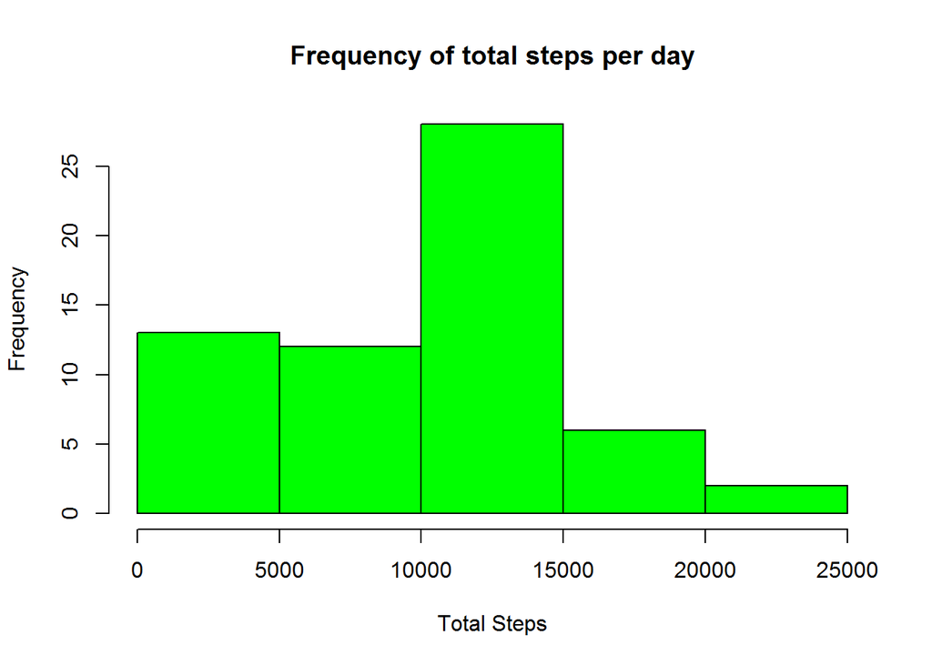

```r
  hist(as.numeric(totalsteps$Total_Steps),main="Frequency of total steps per day",
    xlab="Total Steps",col="green")
```

Calculate and report the mean and median of total steps per day

```r
  meansteps <- mean(totalsteps$Total_Steps,na.rm=TRUE)
    print(meansteps)
```

```
## [1] 9354.23
```

```r
    mediansteps <- median(totalsteps$Total_Steps,na.rm=TRUE)
    print(mediansteps)
```

```
## [1] 10395
```

## Average Daily activity pattern

Create a time series plot of the 5-minute interval (x-axis) and the average number of steps taken, averaged across all days (y-axis)

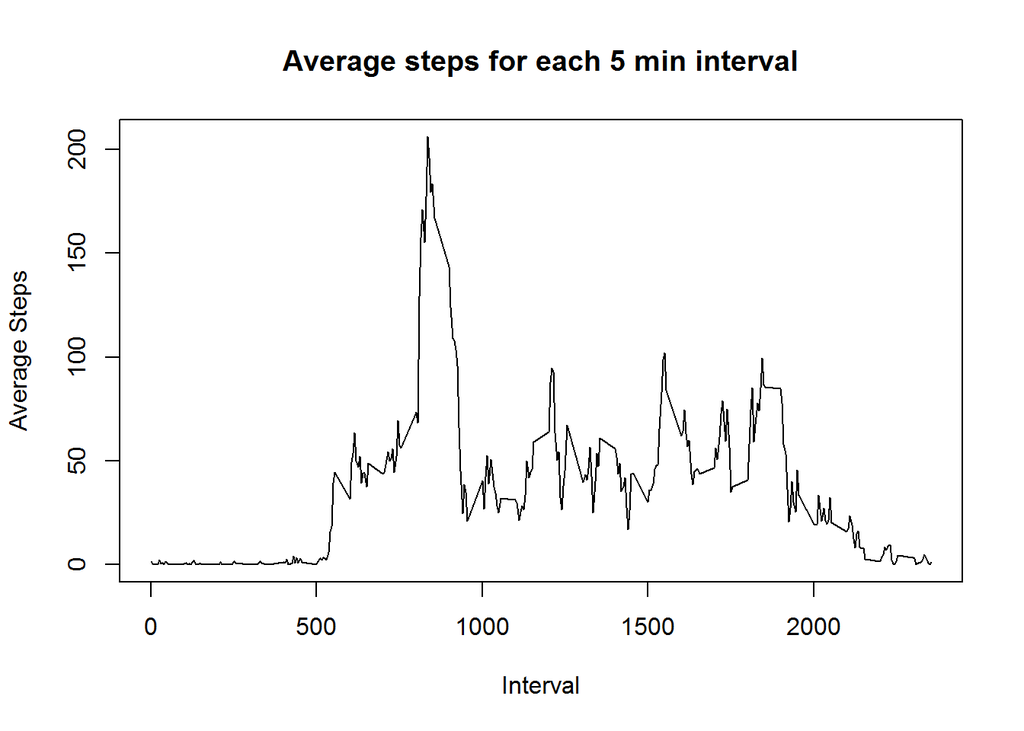

```r
  avgsteps <- aggregate(data$steps,by=list(data$interval),mean,na.rm=TRUE)
    colnames(avgsteps) <- c("Interval","Avg_Steps")
    with(avgsteps,plot(Interval, Avg_Steps,type="l"
        ,main="Average steps for each 5 min interval",
          ylab="Average Steps",xlab="Interval"))
```

Calculate the 5 minute interval with the largest average steps across all days

```r
  maxavgint <- subset(avgsteps,Avg_Steps == max(avgsteps$Avg_Steps))
    print(maxavgint)
```

```
##     Interval Avg_Steps
## 104      835  206.1698
```

## Imputing missing values

Calculate the number of missing values in dataset

```r
  totalNA <- colSums(is.na(data))
    print(totalNA)
```

```
##    steps     date interval
##     2304        0        0
```

Replace NA values with the mean across days for the interval with the NA rounded to a whole integer

```r
  imputed <- data
      for (i in 1:nrow(imputed))
      {
            if (is.na(imputed$steps[i]))
            {
            imputed$steps[i] <- round(avgsteps[which(imputed$interval[i]
                    == avgsteps$Interval),]$Avg_Steps)
            }
    }
    totalNAimputed <- colSums(is.na(imputed))
    print(totalNAimputed)
```

```
##    steps     date interval
##        0        0        0
```

Calculate number of steps taken per day with imputed data

```r
  totalstepsimputed <- aggregate(imputed$steps,by=list(imputed$date),sum)
    colnames(totalstepsimputed) <- c("Date","Total_Steps")
```

Create histogram of total steps taken per day

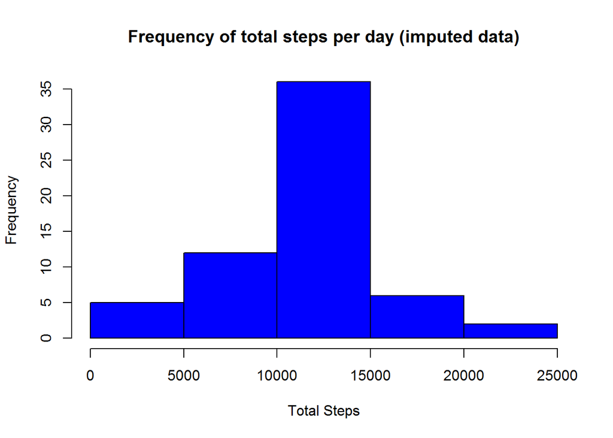

```r
  hist(as.numeric(totalstepsimputed$Total_Steps),
        main="Frequency of total steps per day (imputed data)",
        xlab="Total Steps",col="blue")
```

Calculate and report the mean and median of total steps per day

```r
  meanstepsimputed <- mean(totalstepsimputed$Total_Steps)
    print(meanstepsimputed)
```

```
## [1] 10765.64
```

```r
    medianstepsimputed <- median(totalstepsimputed$Total_Steps)
    print(medianstepsimputed)
```

```
## [1] 10762
```

Compare mean and median from data with missing values to data without

```r
  diff_mean <- abs(meansteps - meanstepsimputed)
    print(diff_mean)
```

```
## [1] 1411.41
```

```r
    diff_median <- abs(mediansteps - medianstepsimputed)
    print(diff_median)
```

```
## [1] 367
```

## Differences in activity between weekends and weekdays

Create new variable indicating whether the date is a weekend or weekday

```r
    imputed$Weekday_Weekend <- weekdays(as.Date(imputed$date,"%Y-%m-%d"))
    imputed$Weekday_Weekend <- gsub("Monday","Weekday",imputed$Weekday_Weekend)
    imputed$Weekday_Weekend <- gsub("Tuesday","Weekday",imputed$Weekday_Weekend)
    imputed$Weekday_Weekend <- gsub("Wednesday","Weekday",imputed$Weekday_Weekend)
    imputed$Weekday_Weekend <- gsub("Thursday","Weekday",imputed$Weekday_Weekend)
    imputed$Weekday_Weekend <- gsub("Friday","Weekday",imputed$Weekday_Weekend)
    imputed$Weekday_Weekend <- gsub("Saturday","Weekend",imputed$Weekday_Weekend)
    imputed$Weekday_Weekend <- gsub("Sunday","Weekend",imputed$Weekday_Weekend)
```

Create a panel plot containing a time series plot of the 5-minute interval and the average number of steps taken, averaged across all weekday days or weekend days.

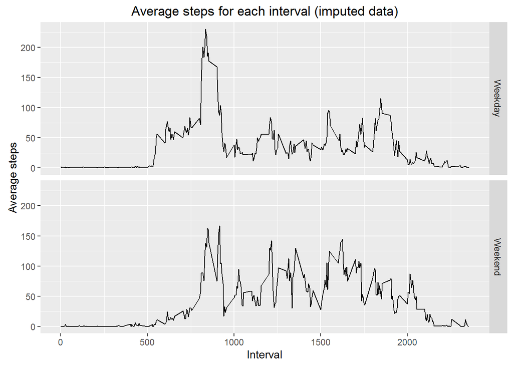

```r
  avgsteps2 <- aggregate(imputed$steps,by=list(interval=imputed$interval,
    weekday=imputed$Weekday_Weekend),mean)
    colnames(avgsteps2) <- c("Interval","Weektime","Avg_Steps")
    library(ggplot2)
    with(avgsteps2,qplot(Interval, Avg_Steps,geom="line",facets=Weektime~.,
        main="Average steps for each interval (imputed data)",xlab="Interval",
        ylab="Average steps"))
```